# Geographic Trends

plimasalle

11/28/2018

## 1. Upload Data

*Used the version that is found in the repository. However, I opened it as a *xls* file and not a *cvs* file before I did anything to have a better look at the data.*

## 2. Clean Data

*For simplicity’s sake, I am looking at which zipcodes had the most inspections overall.*

## 3. Gathered Geocodes

*Please download the `zipcode` package in R.*

## 4. Finalized Dataset

*I wanted the specific neighborhood names for easier interpretation of the trends, so I got each zipcode’s location. However, many locations were just labeled as “Boston” so I manually searched nearby landmarks to get a better sense of the area. I deleted one row because the zipcode list did not have any matching points. (UPDATE: Because I was able to get the map to work, I don’t think the actual neighborhoods are important / might weaken our analysis because it adds an element of bias.)*

## 5. Generate a Map of Boston

```
## Google Maps API Terms of Service: https://cloud.google.com/maps-platform/terms/.
```

## 6. Create Shapefile of Boston

*Please download the `rgdal` package in R.*

[output not shown]

[output not shown]

[output not shown]

[output cut: 97 more lines]

[output not shown]

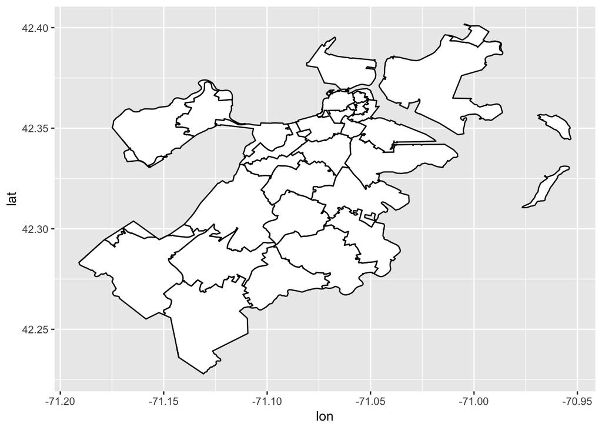

## 7. Final Output

*(a) Join map and shapefile dataframes by zipcode (b) Overlay the two maps together (c) Create heat map visualization (d) Add labels (NOTE: I wasn’t able to align the two maps perfectly, but I think the final output still works for this project)*

[figure not shown]